# Results 1 - Gold

These results represents the first actual results to speak of after some time of training, it was quite big to see them come in.

1. load models
2. obtain P and Q values
3. buy and hold
4. plot results
5. obtain and plot sharpe ratio
6. setup other strategies
7. compare results

```python
import numpy as np
import matplotlib.pyplot as plt
import seaborn as sns
import pandas as pd

from tensorflow.keras.models import load_model

from RESULTS_stage8_HELPERS import Stage8_Helpers
```

## Load Models

```python
helpers = Stage8_Helpers()
# Local
local_3249 = load_model('local1_model_3249')
local_9499 = load_model('local1_model_9499')
local_14499 = load_model('local1_model_14499')
local_19249 = load_model('local1_model_19249')
# GPU3
gpu3_7249 = load_model('gpu3_model_7249')
gpu3_9499 = load_model('gpu3_model_9499')
gpu3_11499 = load_model('gpu3_model_11499')
gpu3_9249 = load_model('gpu3_model_9249')
# GPU4
gpu4_8749 = load_model('gpu4_model_8749')
```

## Obtain P and Q Values

```python
# Local
local_3249_P, local_3249_Q, sharpe1  = helpers.get_p_values(local_3249)
local_9499_P, local_9499_Q, _ = helpers.get_p_values(local_9499)
local_14499_P, local_14499_Q, _ = helpers.get_p_values(local_14499)
local_19249_P, local_19249_Q, _ = helpers.get_p_values(local_19249)
# GPU3
gpu3_7249_P, gpu3_7249_Q, _ = helpers.get_p_values(gpu3_7249)
gpu3_9499_P, gpu3_9499_Q, _ = helpers.get_p_values(gpu3_9499)
gpu3_11499_P, gpu3_11499_Q, _ = helpers.get_p_values(gpu3_11499)
gpu3_9249_P, gpu3_9249_Q, sharpe2 = helpers.get_p_values(gpu3_9249)
# GPU4
gpu4_8749_P, gpu4_8749_Q, _ = helpers.get_p_values(gpu4_8749)
```

## Buy and Hold

This means that you obtain a fully exposed position to the market at all time. You buy and sit on it. In effect this means that you follow the underlying assets movements.

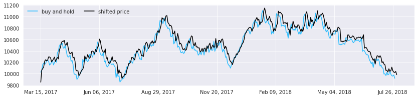

```python
# Various goodies
data, test, train, df2 = helpers.get_data()
init_cash = 10000
cmap = ['#2CBDFE', '#47DBCD', '#F3A0F2', 'yellow', '#661D98', '#F5B14C',
        'm', 'k', 'purple', 'pink', 'orange', 'blue', 'green']
sns.set_style('darkgrid')
ticks = [i for i in range(0, 365, 365 // 6)]
dates = [data['date'].iloc[len(data) - 365:].iloc[i] for i in range(0, 365, 365 // 6)]

BH = []
BH_count = init_cash
for i in df2['Price'][len(df2) - len(test) + 2: ]:
    BH_count = BH_count * (1 + i)
    BH.append(BH_count)
plt.figure(figsize=(14, 3))
plt.plot(BH, cmap[0], label='buy and hold')
plt.plot(test['price'] * 8 + 250, cmap[7], label='shifted price')
plt.legend(loc='best', frameon=False, ncol=2)
plt.xticks(ticks, dates)
plt.show()
```

## Plot in Various Ways

As we can see below, our agent have adopted a strategy that has yielded an overall more profitable result. This is big.

Lets see the results from three models as they compare to the results from various training times.

We will pick the local 3249, gpu3 and gpu4 results.

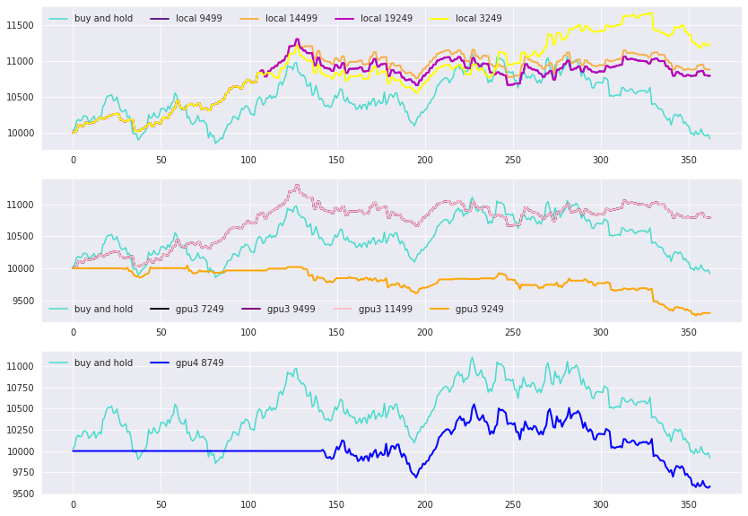

```python
plt.figure(figsize=(14, 10))
# Local
plt.subplot(3, 1, 1)
plt.plot(BH, cmap[1], label='buy and hold')
plt.plot(local_9499_P, cmap[4], linewidth=2, label='local 9499')
plt.plot(local_14499_P, cmap[5], linewidth=2, label='local 14499')
plt.plot(local_19249_P, cmap[6], linewidth=2, label='local 19249')
plt.plot(local_3249_P, cmap[3], linewidth=2, label='local 3249')
plt.legend(loc='best', frameon=False, ncol=5)
# GPU3
plt.subplot(3, 1, 2)
plt.plot(BH, cmap[1], label='buy and hold')
plt.plot(gpu3_7249_P, cmap[7], linewidth=2, label='gpu3 7249')
plt.plot(gpu3_9499_P, cmap[8], linewidth=2, label='gpu3 9499')
plt.plot(gpu3_11499_P, cmap[9], linewidth=2, label='gpu3 11499')
plt.plot(gpu3_9249_P, cmap[10], linewidth=2, label='gpu3 9249')
plt.legend(loc='best', frameon=False, ncol=5)
# GPU4
plt.subplot(3, 1, 3)
plt.plot(BH, cmap[1], label='buy and hold')
plt.plot(gpu4_8749_P, cmap[11], linewidth=2, label='gpu4 8749')
plt.legend(loc='best', frameon=False, ncol=2)
plt.show()
```

#### VS random

Lets obtain 100 random runs, average it and plot it against what we got.

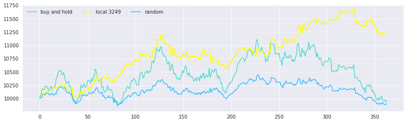

```python
Random = []
for i in range(100):
    random, sharpe_random = helpers.get_p_values(local_3249, random=True)
    Random.append(random)
Random = np.average(Random, axis=0)

plt.figure(figsize=(14, 4))
plt.plot(BH, cmap[1], label='buy and hold')
plt.plot(local_3249_P, cmap[3], linewidth=2, label='local 3249')
plt.plot(Random, cmap[0], label='random')
plt.legend(loc='best', frameon=False, ncol=3)
plt.show()
```

## Sharpe Ratio

The sharpe ratio compares the investment with a risk free asset.

Lets compare with the gpu3_9249 and random to get some perspective.

Usually, any Sharpe ratio greater than 1.0 is considered acceptable to good by investors.

- A ratio higher than 2.0 is rated as very good.
- A ratio of 3.0 or higher is considered excellent.
- A ratio under 1.0 is considered sub-optimal.

## Information Ratio

It is similar to sharpe ratio but instead of using a risk free return as benchmark, it uses a risky index, such as the S&P500 or the [OMX Stockholm 30 Index (OMXS30)](https://indexes.nasdaqomx.com/Index/Overview/OMXS30) which we use here.

## Benchmarks

Let the curves below represent the official metrics that we will want to outperform with upcoming model improvements, that is:

- **Log returns:** increase the area between model and asset.
- **Sharpe ratio:** with respect to zero as riskfree asset. Sure, we can use this aswell.
- **information ratio:** this one feels like the truly useful one. Here we do not only see how the model stands with respect to the asset it is trained on, but on other real assets as well. Lets run coming improvements against omx to start with, then we can fill it up with more.

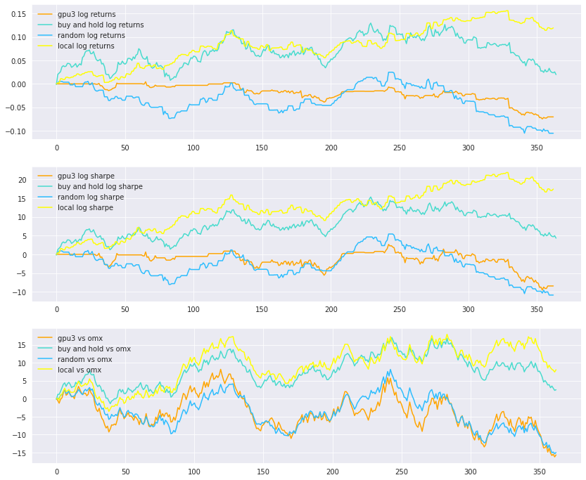

```python
def get_log(data):
    '''Computes the log returns of given data.'''
    log_r = []
    count = 0
    for i in data:
        if i >= 0:
            count = count + np.log(1 + abs(i) + 0.000001)
        if i < 0:
            count = count - np.log(1 + abs(i) + 0.000001)
        log_r.append(count)
    return log_r
plt.figure(figsize=(14, 12))
# log returns
plt.subplot(3, 1, 1)
plt.plot(get_log(sharpe2), cmap[10], label='gpu3 log returns')
plt.plot(get_log(test['close']), cmap[1], label='buy and hold log returns')
plt.plot(get_log(sharpe_random), cmap[0], label='random log returns')
plt.plot(get_log(sharpe1), cmap[3], label='local log returns')
plt.legend(loc='best', frameon=False, ncol=1)
# got sharpe
plt.subplot(3, 1, 2)
plt.plot(get_log(sharpe2 / np.std(sharpe2)), cmap[10], label='gpu3 log sharpe')
plt.plot(get_log(test['close'] / np.std(test['close'])), cmap[1], label='buy and hold log sharpe')
plt.plot(get_log(sharpe_random / np.std(sharpe_random)), cmap[0], label='random log sharpe')
plt.plot(get_log(sharpe1 / np.std(sharpe1)), cmap[3], label='local log sharpe')
plt.legend(loc='best', frameon=False, ncol=1)
# information ratio
# get omx data (insert 17 zeros to fit, sloppy)
omx = pd.read_csv('omx30.csv', sep=';',header=1)
omx = omx[::-1][7999 - 347:]['Stängn.kurs']
omx = [float(i.replace(',', '.')) for i in omx]
omx = pd.Series(omx).pct_change()[1:].to_list()
for i in range(0, len(omx), len(omx) // 16):
    omx.insert(i, 0)
omx = np.array(omx)
plt.subplot(3, 1, 3)
plt.plot(get_log((sharpe2 - omx) / np.std(sharpe2)), cmap[10], label='gpu3 vs omx')
plt.plot(get_log((test['close'][:-2] - omx) / np.std(test['close'])), cmap[1], label='buy and hold vs omx')
plt.plot(get_log((sharpe_random - omx) / np.std(sharpe_random)), cmap[0], label='random vs omx')
plt.plot(get_log((sharpe1 - omx) / np.std(sharpe1)), cmap[3], label='local vs omx')
plt.legend(loc='best', frameon=False, ncol=1)
plt.show()
```

## Inference on Training Data

Running inference on the full gold dataset and as we can see there are alot of gains to make here.

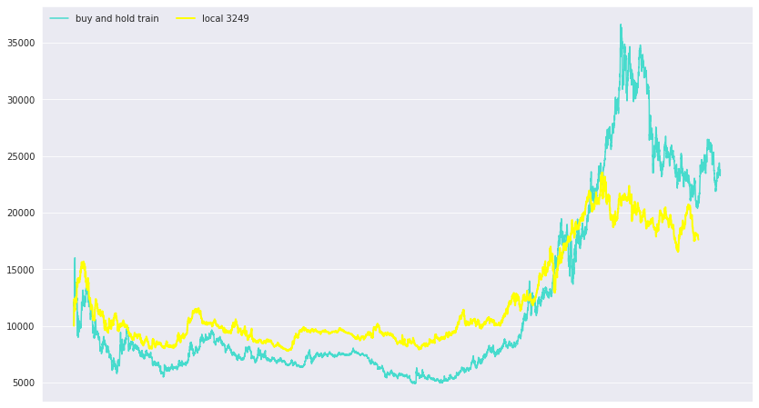

```python
### do inference on the full dataset
train_data = helpers.get_p_values(local_3249, full=True)
BH_train = []
BH_count = init_cash
for i in df2['Price'][: len(df2) - len(test) + 2]:
    BH_count = BH_count * (1 + i)
    BH_train.append(BH_count)
plt.figure(figsize=(14, 8))
plt.plot(BH_train, cmap[1], label='buy and hold train')
plt.plot(train_data[0], cmap[3], linewidth=2, label='local 3249')
plt.legend(loc='best', frameon=False, ncol=2)
plt.xticks([])
plt.show()
```